# FimH_Var_Analysis

Flores-Oropeza MA.

2022-05

## Polymorphisms identification in the FimH adhesine of Uropathogenic *Escherichia coli*: Colonization and virulence effect in HTB-5 human bladder cells.

### Introduction.

The adherence is the interaction of a microorganism to a biotic or abiotic surface, this interaction is mediated by proteic structures named fimbriae. These can contain one or more specialized subunits named adhesins (McLay *et al*., 2018). For the enterobacteria such Escherichia coli, the type 1 fimbria is expressed a long and thin appendix that contains at its apical end the adhesin FimH (Tseng *et. al.*, 2020). The commensal strains are restricted to the interaction with tri-mannosylated residues such as those present in the cells of the intestine, but in *E. coli* (UPEC), binding to mono-mannosylated residues, abundant in the bladder, is increased, generating a specialized tropism (Sokurenko *et. al.*, 1998). This has its origin in the FimH alleles defined by mutations of a single nucleotide, which cause structural changes and that they have an important effect if they are within the mannose binding domain (Paul *et. al.,* 2013). They are associated with colonization, persistence and severity of the infection.

### Justification.

The identification of natural alleles in Mexican clinical strains has not been reported so far, the prevalence of an allele and its identification could be helpful in optimizing a FimH-based vaccine against UPEC.

### Goal.

The objective of this project its do an analysis of the sequences of FimH gene, and use statistical analysis .

### Preparation of the database.

Performed a search of the NCBI database, retrieved all complete genome sequences of E. coli associated with the urinary tract.

```r
#Set working directory
setwd("./")
```

```r
library(readr)
#Load the data base of the strains to work.
database <- read.delim("./results/traits/database.txt", row.names=1, comment.char="#")
head(database)
```

```
##              O   H Serotype    MLST Phylogroup              Country
## 81009      O25  H4    O25H4      43        B2  United-Arab-Emirates
## M160133    O15 H45   O15H45 Not Hit          F                  USA
## CH611_eco O101  H9   O101H9     741          A                China
## XH990      O86 H51   O86H51      31          D                China
## XH990.2    O86 H51   O86H51      31          D                China
## XH992     O153 H34  O153H34      39          F                China
##                              Disease Year
## 81009                           AUTI 2009
## M160133                         AUTI 2016
## CH611_eco Intra-abdominal infections 2015
## XH990            Intracranial_Injury 2016
## XH990.2          Intracranial_Injury 2016
## XH992            Intracranial_Injury 2016
```

This script its a sequence report of the analysis of FimH sequences.

```r
#Load the next libraries.
library(dplyr)
```

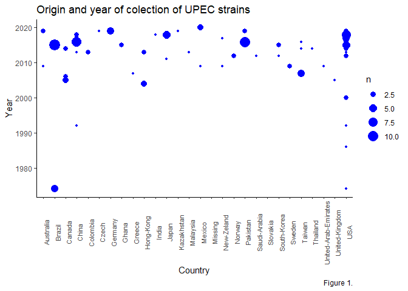

```r
library(ggplot2)
#Create a graphic
Genomes_Year_Country <- ggplot (data = database, mapping = aes(x = Country, y= Year)) + geom_count(color="Blue") + labs(title = "Origin and year of colection of UPEC strains", caption = "Figure 1.") + theme_classic() + theme(axis.text.x = element_text(size=8, angle=90))
Genomes_Year_Country
```

However, we can also analyse the data using a four variable graphic. In this case, we only select the two groups that we are more interested. The Urinary tract Infections (UTI) versus the Recurrent ITU.

```r
#Use the filter option to make a new table with only RUTI
RUTI<- database %>% filter(Disease=="RUTI")
UTI<- database %>% filter(Disease=="UTI")
nrow(RUTI)
```

```
## [1] 22
```

```r
nrow(UTI)
```

```
## [1] 83
```

```r
RUTI_vs_UTI<-rbind(RUTI,UTI)
nrow(RUTI_vs_UTI)
```

```
## [1] 105
```

With this new data we can make a graphic that allow four variables to compare the UTI vs RUTI strains.

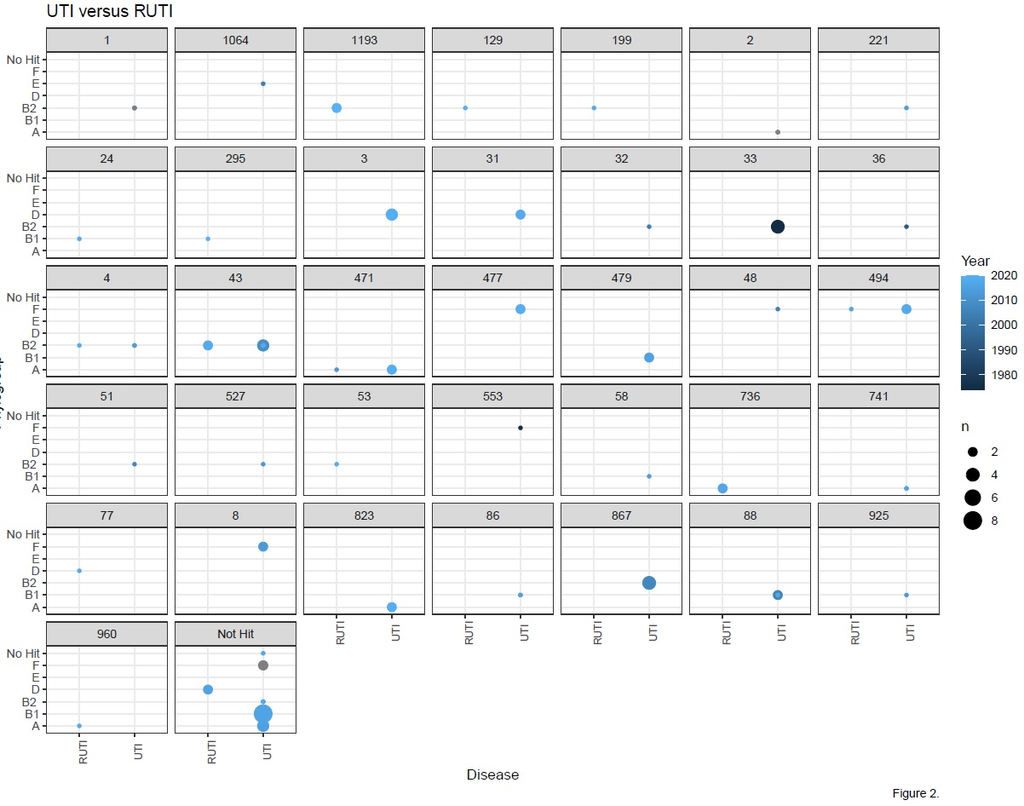

```r
fimH_database <- read.delim("./data/FimH_pb.txt", header = FALSE)
head (fimH_database)
```

```
##                                                                                 V1
## 1                                                                         >00-3076
## 2 ATGAAACGAGTTATTACCCTGTTTGCTGTACTGCTGATGGGCTGGTCGGTAAATGCCTGGTCATTCGCCTGTAAAACCGC
## 3 CAATGGTACAGCTATCCCTATTGGCGGTGGCAGCGCTAATGTTTATGTAAACCTTGCGCCTGCCGTGAATGTGGGGCAAA
## 4 ACCTGGTCGTAGATCTTTCGACGCAAATCTTTTGCCATAACGATTATCCGGAAACCATTACAGACTATGTCACACTGCAA
## 5 CGAGGCTCGGCTTATGGCGGCGTGTTATCTAATTTTTCCGGGACCGTAAAATATAGTGGCAGTAGCTATCCATTTCCGAC
## 6 CACCAGCGAAACGCCGCGGGTTGTTTATAATTCGAGAACGGATAAGCCGTGGCCGGTGGCGCTTTATTTGACGCCTGTGA
```

This data base was analyse using the Mesquite program, in this scenario a alignment with Clustal W and tree was performed. The data showed that the RUTI strains are located around of the UTI. Cleary that the FimH allele are not related with the RUTI phenotype.

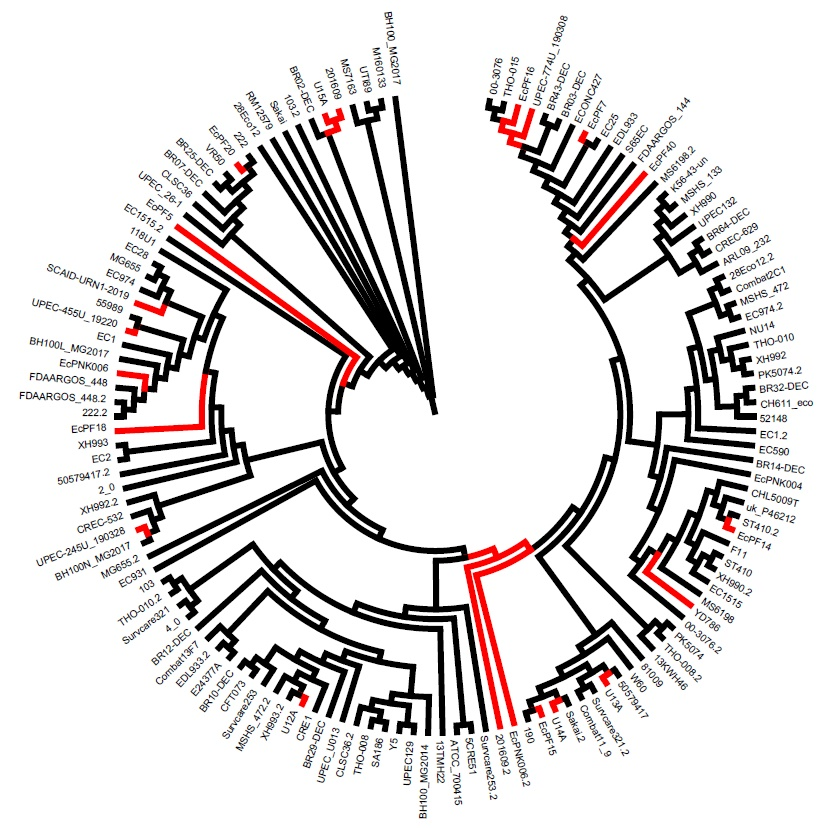

However, with the Beauti and Beast programs, we develop a Bayesian analysis, to obtain a likelihood probability, based in RUTI trait.

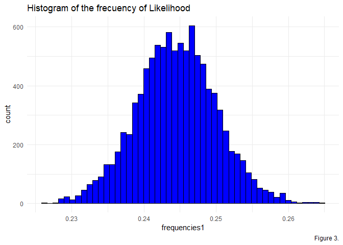

```r
#Import data set of Beast. *.log data contain, likelihood, frecuency, position.
FimH_pb.log <- read.delim("~/GitHub/FimH_Variations/data/FimH_pb.log.txt", comment.char="#")
#With a frecuency graphic we can considerate if there are a posible selection.
frecuency<-ggplot(FimH_pb.log, aes(x=frequencies1)) + geom_histogram(bins = 50, color = "black", fill = "blue") + theme_minimal() +labs(title = "Histogram of the frecuency of Likelihood", caption = "Figure 3.")
frecuency
```

In the graphic of frequency, we can see that the data are centered, indicative that maybe we don’t have a selective presion. Also, the calculate likelihood it is not significative, because the results are minor to zero.

```r
neutral<-subset(FimH_pb.log,FimH_pb.log$likelihood > 0)
problem<-subset(FimH_pb.log,FimH_pb.log$treeLikelihood >0)
neutral
```

```
##  [1] state                joint                prior
##  [4] likelihood           treeModel.rootHeight age.root.
##  [7] treeLength           tmrca.RUTI.          age.RUTI.
## [10] constant.popSize     kappa                frequencies1
## [13] frequencies2         frequencies3         frequencies4
## [16] clock.rate           meanRate             treeLikelihood
## [19] branchRates          coalescent
## <0 rows> (or 0-length row.names)
```

```r
problem
```

```
##  [1] state                joint                prior
##  [4] likelihood           treeModel.rootHeight age.root.
##  [7] treeLength           tmrca.RUTI.          age.RUTI.
## [10] constant.popSize     kappa                frequencies1
## [13] frequencies2         frequencies3         frequencies4
## [16] clock.rate           meanRate             treeLikelihood
## [19] branchRates          coalescent
## <0 rows> (or 0-length row.names)
```

### Conclusions

There are not signs of adtaptative evolution in fimH gene from a Bayesian analysis of RUTI versus ITU.

### Bibliografía:

McLay, R. B., *et al.*, (2018). 34(3), 1133-1142.

Tseng, C. C., *et al.*, (2020).

Sokurenko, E. *et al.*, (1998). 95(15), 8922-8926.

Paul, S., *et al.*, (2013). 195(2), 231-242.

Joensen, K. G., *et al.*, (2015). *53*(8), 2410-2426.

[output not shown]